# Caret / Recursive Partitioning

### Questions:

- Discuss the difference between the models and why you would use one model over the other?

It depends on what my audience was and who was going to be using the model. Since rules-based / decision tree models are both highly interpretable and easy to use to predict new data, if this was a model that was going to be used by non-programmer/analytics people I would prefer to use this model. However, I think there are better ways to tweak the logsitic regression model to get a prefered business outcome by changing the specificy and sensitivy (aka moving along the ROC curve) to limit Type I and Type II errors, depending on their cost.

- How might you produce an ROC type curve for the *rpart* model?

```r
# calculate and plot an ROC curve for the rpart model

pred_test <- predict(fit3, newdata=test2, type="prob")[,2]

str(pred_test)
```

```
##  Named num [1:81835] 0.0691 0.0691 0.0691 0.0691 0.0691 ...
##  - attr(*, "names")= chr [1:81835] "1" "2" "3" "4" ...
```

```r
fit3_auc <- roc(test2$late, pred_test)
fit3_auc
```

```
##
## Call:
## roc.default(response = test2$late, predictor = pred_test)
##
## Data: pred_test in 65596 controls (test2$late FALSE) < 16239 cases (test2$late TRUE).
## Area under the curve: 0.8428
```

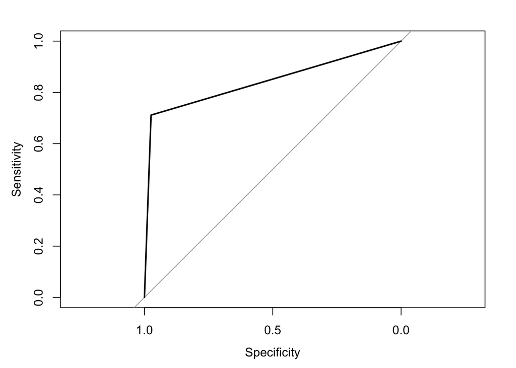

```r
plot(fit3_auc)
```